# Sama Amr Habib - Data analysis

## Digital wallet transaction

#### Dataset Description

Digital Wallet Transactions dataset contains details of digital financial activities for a digital wallet platform, with 5000 synthetic records covering last year. The dataset spans various features reflecting real-world digital wallet functionalities. With dynamic transaction dates, it provides an excellent foundation for analyzing spending patterns, evaluating cashback effectiveness, and exploring seasonal trends in digital wallet usage. This dataset is ideal for uncovering insights into user behavior, merchant popularity, and potential fraud detection.

Kaggle Dataset Source: https://www.kaggle.com/datasets/harunrai/digital-wallet-transactions

#### Overview:

```
This dataset simulates transactions from a digital wallet platform similar to popular services like PayTm in India or Khalti in Nepal. It contains 5000 synthetic records of various financial transactions across multiple categories, providing a rich source for analysis of digital payment behaviors and trends.
```

#### Potential Use Cases

Analyzing spending patterns across different product categories Studying the effectiveness of cashback and loyalty programs Investigating the relationship between payment methods and transaction success rates Exploring seasonal trends in digital wallet usage Developing fraud detection models based on transaction patterns Segmenting users based on their spending behavior Analyzing the popularity of different merchants and services

```python
import numpy as np
import pandas as pd
import matplotlib.pyplot as plt
import seaborn as sns
import warnings
```

```python
df=pd.read_csv('digital_wallet_transactions.csv')
```

```python
df.head()
```

|  | idx | transaction_id | user_id | transaction_date | product_category | product_name | merchant_name | product_amount | transaction_fee | cashback | loyalty_points | payment_method | transaction_status | merchant_id | device_type | location |
| --- | --- | --- | --- | --- | --- | --- | --- | --- | --- | --- | --- | --- | --- | --- | --- | --- |
| 0 | 1 | 4dac3ea3-6492-46ec-80b8-dc45c3ad0b14 | USER_05159 | 2023-08-19 03:32 | Rent Payment | 2BHK Flat Deposit | Airbnb | 1525.39 | 36.69 | 19.19 | 186 | Debit Card | Successful | MERCH_0083 | iOS | Urban |
| 1 | 2 | a903ed9f-eb84-47e7-b8aa-fd1786c919cf | USER_07204 | 2023-08-19 04:37 | Gas Bill | Commercial Gas Connection | Adani Gas | 1495.40 | 28.19 | 89.99 | 182 | UPI | Successful | MERCH_0163 | iOS | Urban |
| 2 | 3 | 2a393013-733c-4add-9f09-bed1eeb33676 | USER_00903 | 2023-08-19 05:52 | Bus Ticket | Semi-Sleeper | MakeMyTrip Bus | 1267.71 | 11.36 | 95.70 | 994 | UPI | Successful | MERCH_0320 | iOS | Urban |
| 3 | 4 | 9a07ad19-4673-4794-9cd2-9b139f39c715 | USER_01769 | 2023-08-19 06:35 | Internet Bill | 4G Unlimited Plan | Airtel Broadband | 9202.63 | 6.41 | 82.24 | 409 | Debit Card | Successful | MERCH_0194 | Android | Urban |
| 4 | 5 | 76418260-c985-4011-979d-0914604d0d68 | USER_03544 | 2023-08-19 06:36 | Loan Repayment | Home Loan EMI | Axis Bank | 3100.58 | 41.15 | 40.47 | 837 | Debit Card | Successful | MERCH_0504 | Android | Urban |

```python
df.columns
```

```
Index(['idx', 'transaction_id', 'user_id', 'transaction_date',
       'product_category', 'product_name', 'merchant_name', 'product_amount',
       'transaction_fee', 'cashback', 'loyalty_points', 'payment_method',
       'transaction_status', 'merchant_id', 'device_type', 'location'],
      dtype='object')
```

```python
df.info()
```

```
<class 'pandas.core.frame.DataFrame'>
RangeIndex: 5000 entries, 0 to 4999
Data columns (total 16 columns):
 #   Column              Non-Null Count  Dtype
---  ------              --------------  -----
 0   idx                 5000 non-null   int64
 1   transaction_id      5000 non-null   object
 2   user_id             5000 non-null   object
 3   transaction_date    5000 non-null   object
 4   product_category    5000 non-null   object
 5   product_name        5000 non-null   object
 6   merchant_name       5000 non-null   object
 7   product_amount      5000 non-null   float64
 8   transaction_fee     5000 non-null   float64
 9   cashback            5000 non-null   float64
 10  loyalty_points      5000 non-null   int64
 11  payment_method      5000 non-null   object
 12  transaction_status  5000 non-null   object
 13  merchant_id         5000 non-null   object
 14  device_type         5000 non-null   object
 15  location            5000 non-null   object
dtypes: float64(3), int64(2), object(11)
memory usage: 625.1+ KB
```

```python
df.describe()
```

|  | idx | product_amount | transaction_fee | cashback | loyalty_points |
| --- | --- | --- | --- | --- | --- |
| count | 5000.000000 | 5000.000000 | 5000.000000 | 5000.000000 | 5000.000000 |
| mean | 2500.500000 | 4957.502722 | 25.188874 | 50.658782 | 498.790400 |
| std | 1443.520003 | 2885.034160 | 14.535298 | 28.522467 | 288.962434 |
| min | 1.000000 | 10.090000 | 0.010000 | 0.000000 | 0.000000 |
| 25% | 1250.750000 | 2453.977500 | 12.665000 | 26.495000 | 246.000000 |
| 50% | 2500.500000 | 4943.685000 | 25.070000 | 51.390000 | 504.000000 |
| 75% | 3750.250000 | 7444.815000 | 37.947500 | 75.067500 | 749.000000 |
| max | 5000.000000 | 9996.950000 | 49.990000 | 100.000000 | 999.000000 |

```python
df.shape
```

```
(5000, 16)
```

```python
df.dtypes
```

```
idx                     int64
transaction_id         object
user_id                object
transaction_date       object
product_category       object
product_name           object
merchant_name          object
product_amount        float64
transaction_fee       float64
cashback              float64
loyalty_points          int64
payment_method         object
transaction_status     object
merchant_id            object
device_type            object
location               object
dtype: object
```

```python
df.tail()
```

|  | idx | transaction_id | user_id | transaction_date | product_category | product_name | merchant_name | product_amount | transaction_fee | cashback | loyalty_points | payment_method | transaction_status | merchant_id | device_type | location |
| --- | --- | --- | --- | --- | --- | --- | --- | --- | --- | --- | --- | --- | --- | --- | --- | --- |
| 4995 | 4996 | 2cad1456-e6dd-4d0f-9463-a071a462c2ae | USER_03918 | 2024-08-17 19:39 | Internet Bill | 4G Unlimited Plan | BSNL Broadband | 9496.45 | 37.25 | 87.47 | 284 | UPI | Successful | MERCH_0203 | Android | Rural |
| 4996 | 4997 | df3984f6-cf9d-418f-ad2e-f9d4fff69cd5 | USER_09281 | 2024-08-17 19:42 | Education Fee | Python Programming Course | Unacademy | 710.40 | 14.01 | 55.24 | 538 | Credit Card | Successful | MERCH_0480 | iOS | Urban |
| 4997 | 4998 | 1c4cd450-785d-4f4c-a08d-cb7c17db9b0c | USER_05939 | 2024-08-17 23:24 | Movie Ticket | Avengers: Endgame | PVR Cinemas | 2750.06 | 48.69 | 72.10 | 652 | Bank Transfer | Successful | MERCH_0411 | Android | Suburban |
| 4998 | 4999 | f88d6fb3-d747-4963-82f3-92e181a93771 | USER_09925 | 2024-08-18 00:28 | Mobile Recharge | Data Pack 50GB | BSNL | 9976.19 | 21.96 | 40.44 | 614 | UPI | Successful | MERCH_0524 | iOS | Suburban |
| 4999 | 5000 | 5e1a9245-9f2b-4ff9-bd56-26fd20c8eae2 | USER_08419 | 2024-08-18 01:15 | Food Delivery | Vegetable Biryani | Foodpanda | 1683.63 | 11.43 | 70.44 | 936 | UPI | Successful | MERCH_0446 | Web | Urban |

```python
df.isnull().sum()
```

```
idx                   0
transaction_id        0
user_id               0
transaction_date      0
product_category      0
product_name          0
merchant_name         0
product_amount        0
transaction_fee       0
cashback              0
loyalty_points        0
payment_method        0
transaction_status    0
merchant_id           0
device_type           0
location              0
dtype: int64
```

```python
df.duplicated().sum()
```

```
0
```

```python
df.value_counts().sum()
```

```
5000
```

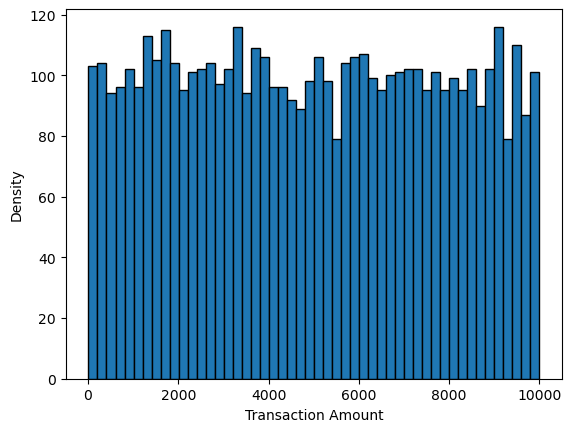

```python
plt.hist(df['product_amount'], bins = 50, edgecolor = 'black')
plt.xlabel('Transaction Amount')
plt.ylabel('Density')
plt.show()
```

```python
category_summary =df.groupby('product_category')[['product_amount']].agg(['sum', 'count'])
category_summary = category_summary.sort_values(by=('product_amount', 'sum') , ascending = False)
category_summary
```

| product_category | product_amount sum | product_amount count |
| --- | --- | --- |
| Streaming Service | 1462461.66 | 299 |
| Water Bill | 1400668.85 | 273 |
| Gas Bill | 1361519.80 | 250 |
| Education Fee | 1349321.77 | 286 |
| Movie Ticket | 1337399.89 | 272 |
| Hotel Booking | 1319603.90 | 274 |
| Food Delivery | 1317106.21 | 259 |
| Taxi Fare | 1306566.24 | 256 |
| Rent Payment | 1258263.69 | 251 |
| Internet Bill | 1247178.07 | 233 |
| Electricity Bill | 1245972.74 | 252 |
| Loan Repayment | 1210681.76 | 245 |
| Online Shopping | 1207396.13 | 243 |
| Mobile Recharge | 1196334.68 | 241 |
| Gaming Credits | 1136665.44 | 231 |
| Grocery Shopping | 1134972.71 | 238 |
| Flight Booking | 1124283.05 | 216 |
| Bus Ticket | 1115711.58 | 235 |
| Insurance Premium | 1032608.99 | 225 |
| Gift Card | 1022796.45 | 221 |

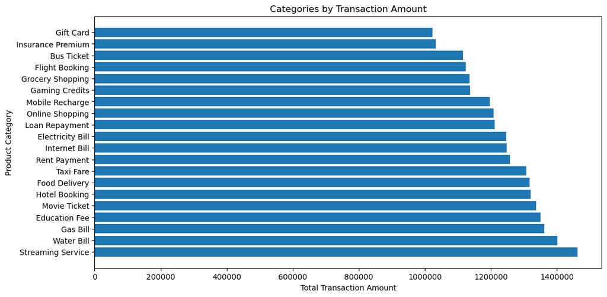

```python
plt.figure(figsize=(12,6))
plt.barh(category_summary.index, category_summary['product_amount']['sum'])
plt.ylabel('Product Category')
plt.xlabel('Total Transaction Amount')
plt.ticklabel_format(axis = 'x' , style = 'plain')
plt.title('Categories by Transaction Amount')
plt.show()
```

Compare categories by Average Transaction Value (ATV).

```python
dfV = df.groupby('product_category')['product_amount'].mean().sort_values(ascending = False).reset_index()
dfV = dfV.rename(columns = {'product_amount' : 'average_transaction_value'})
dfV
```

|  | product_category | average_transaction_value |
| --- | --- | --- |
| 0 | Gas Bill | 5446.079200 |
| 1 | Internet Bill | 5352.695579 |
| 2 | Flight Booking | 5205.014120 |
| 3 | Water Bill | 5130.655128 |
| 4 | Taxi Fare | 5103.774375 |
| 5 | Food Delivery | 5085.352162 |
| 6 | Rent Payment | 5013.002749 |
| 7 | Online Shopping | 4968.708354 |
| 8 | Mobile Recharge | 4964.044315 |
| 9 | Electricity Bill | 4944.336270 |
| 10 | Loan Repayment | 4941.558204 |
| 11 | Gaming Credits | 4920.629610 |
| 12 | Movie Ticket | 4916.911360 |
| 13 | Streaming Service | 4891.176120 |
| 14 | Hotel Booking | 4816.072628 |
| 15 | Grocery Shopping | 4768.792899 |
| 16 | Bus Ticket | 4747.708851 |
| 17 | Education Fee | 4717.908287 |
| 18 | Gift Card | 4628.038235 |
| 19 | Insurance Premium | 4589.373289 |

```python
dfV.describe()
```

|  | average_transaction_value |
| --- | --- |
| count | 20.000000 |
| mean | 4957.591587 |
| std | 221.959028 |
| min | 4589.373289 |
| 25% | 4804.252696 |
| 50% | 4942.947237 |
| 75% | 5089.957715 |
| max | 5446.079200 |

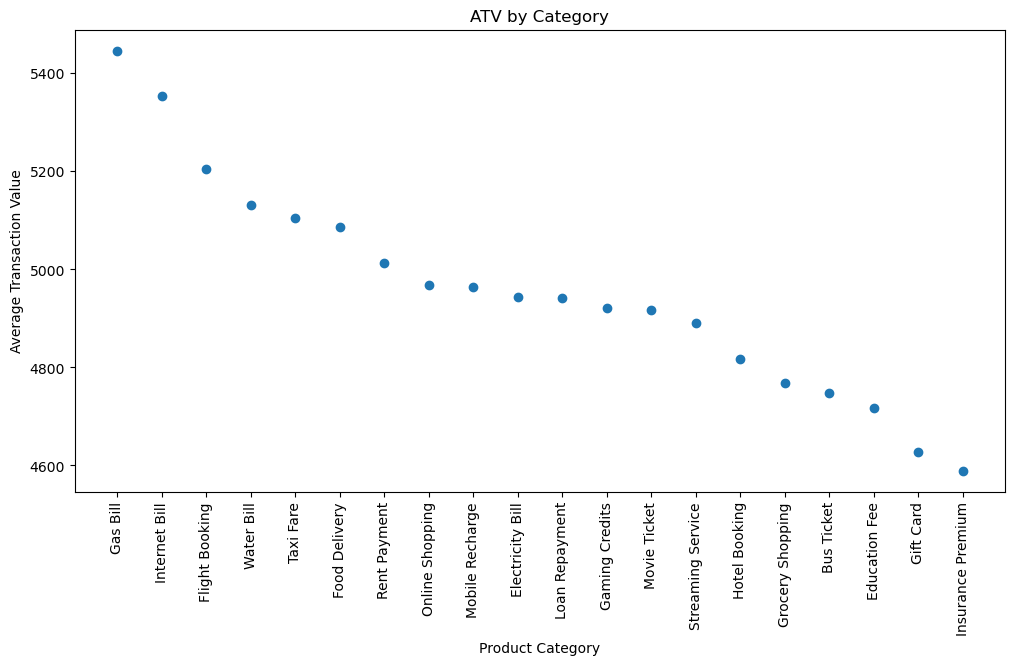

```python
plt.figure(figsize = (12,6))
plt.plot(dfV['product_category'], dfV['average_transaction_value'], 'o')
plt.xlabel('Product Category')
plt.ylabel('Average Transaction Value')
plt.title('ATV by Category')
plt.xticks(rotation = 90)
plt.show()
```